{% raw %}

# Exercises

1. Train model_5 on all of the data in the training dataset for as many epochs until it stops improving. Since this might take a while, you might want to use:
- tf.keras.callbacks.ModelCheckpoint to save the model's best weights only.
- tf.keras.callbacks.EarlyStopping to stop the model from training once the validation loss has stopped improving for ~3 epochs.
2. Checkout the Keras guide on using pretrained GloVe embeddings. Can you get this working with one of our models?
- Hint: You'll want to incorporate it with a custom token Embedding layer.
- It's up to you whether or not you fine-tune the GloVe embeddings or leave them frozen.
3. Try replacing the TensorFlow Hub Universal Sentence Encoder pretrained embedding for the TensorFlow Hub BERT PubMed expert (a language model pretrained on PubMed texts) pretrained embedding. Does this effect results?
- Note: Using the BERT PubMed expert pretrained embedding requires an extra preprocessing step for sequences (as detailed in the TensorFlow Hub guide).
- Does the BERT model beat the results mentioned in this paper? https://arxiv.org/pdf/1710.06071.pdf
4. What happens if you were to merge our line_number and total_lines features for each sequence? For example, created a X_of_Y feature instead? Does this effect model performance?
- Another example: line_number=1 and total_lines=11 turns into line_of_X=1_of_11.
5. Write a function (or series of functions) to take a sample abstract string, preprocess it (in the same way our model has been trained), make a prediction on each sequence in the abstract and return the abstract in the format:
- PREDICTED_LABEL: SEQUENCE
- PREDICTED_LABEL: SEQUENCE
- PREDICTED_LABEL: SEQUENCE
- PREDICTED_LABEL: SEQUENCE
- ...
  - You can find your own unstrcutured RCT abstract from PubMed or try this one from: Baclofen promotes alcohol abstinence in alcohol dependent cirrhotic patients with hepatitis C virus (HCV) infection.

## 1. Train model_5 on all of the data in the training dataset for as many epochs until it stops improving. Since this might take a while, you might want to use:

- tf.keras.callbacks.ModelCheckpoint to save the model's best weights only.
- tf.keras.callbacks.EarlyStopping to stop the model from training once the validation loss has stopped improving for ~3 epochs.

To speed up the training process, I will move all training code onto Googlecolab, and retrieve the calculated results in addition with the trained model into this notebook - However, I will copy paste the code where changes were made, to satisfy the two above bullet points.

```python
# added code
class HubEmbeddingLayer(layers.Layer):
    def __init__(self, hub_layer, **kwargs):
        super().__init__(**kwargs)
        self.hub_layer = hub_layer

    def call(self, inputs):
        return self.hub_layer(inputs)
```

```python
tf_hub_embedding_layer = hub.KerasLayer(
    "https://tfhub.dev/google/universal-sentence-encoder/4",
    trainable=False,
    name="universal_sentence_encoder"
)
```

The code was added on the above, because `token_embeddings = tf_hub_embedding_layer(token_inputs)` was apparently illegal in Google Colab, with the way it did tf and keras 3.

So it was replaced with this:

```
token_embeddings = HubEmbeddingLayer(tf_hub_embedding_layer)(
    token_inputs
)
```

With the added code before the model architecture creation, everything seemed to have worked :)

Now we also add the early stopping and model checkpoint to our model - but before that happens, we'll apply it first with the `tf.keras` variables as below:

```python
# setup earlystopping callback to stop training if model's val_loss doesn't improve for 3 epochs
early_stopping=tf.keras.callbacks.EarlyStopping(monitor='val_loss', # watch the val loss metric
                                                patience=3) # if val loss doesn't improve for 3 epochs in a row, stop training

# create ModelCheckpoint callback to save best model during fine-tuning
checkpoint_path='fine_tune_checkpoints/.keras'
model_checkpoint=tf.keras.callbacks.ModelCheckpoint(checkpoint_path,
                                                    save_best_only=True,
                                                    monitor='val_loss')
```

Now we can apply the changes to our model fitting, where the `0.1` is removed (as we're multiplying by 0.1 on full data, giving us 10% training data only), while also adding our callbacks of `model_checkpoint` and `early_stopping` extras to the model.

Now to play the waiting game.

```python
# Fit the token, char and positional embedding model
history_model_5 = model_5.fit(train_pos_char_token_dataset,
                              steps_per_epoch=int(len(train_pos_char_token_dataset)),
                              epochs=1000,
                              validation_data=val_pos_char_token_dataset,
                              validation_steps=int(len(val_pos_char_token_dataset)),
                              callbacks=[model_checkpoint,early_stopping])
```

So this is the output given, when there is no limitation in training epochs, and on full dataset:

```
Epoch 1/1000
5627/5627 ━━━━━━━━━━━━━━━━━━━━ 1357s 239ms/step - accuracy: 0.7820 - loss: 1.0113 - val_accuracy: 0.8475 - val_loss: 0.9084
Epoch 2/1000
5627/5627 ━━━━━━━━━━━━━━━━━━━━ 1341s 238ms/step - accuracy: 0.8510 - loss: 0.9143 - val_accuracy: 0.8536 - val_loss: 0.8991
Epoch 3/1000
5627/5627 ━━━━━━━━━━━━━━━━━━━━ 1342s 238ms/step - accuracy: 0.8600 - loss: 0.9012 - val_accuracy: 0.8544 - val_loss: 0.8975
Epoch 4/1000
5627/5627 ━━━━━━━━━━━━━━━━━━━━ 1342s 239ms/step - accuracy: 0.8671 - loss: 0.8921 - val_accuracy: 0.8550 - val_loss: 0.8971
Epoch 5/1000
5627/5627 ━━━━━━━━━━━━━━━━━━━━ 1354s 241ms/step - accuracy: 0.8720 - loss: 0.8853 - val_accuracy: 0.8551 - val_loss: 0.8973
Epoch 6/1000
5627/5627 ━━━━━━━━━━━━━━━━━━━━ 1375s 236ms/step - accuracy: 0.8761 - loss: 0.8790 - val_accuracy: 0.8544 - val_loss: 0.8973
Epoch 7/1000
5627/5627 ━━━━━━━━━━━━━━━━━━━━ 1374s 241ms/step - accuracy: 0.8797 - loss: 0.8738 - val_accuracy: 0.8535 - val_loss: 0.8987
```

Then our previous `model_5` results:

```
Epoch 1/3
562/562 [==============================] - 54s 82ms/step - loss: 1.1041 - accuracy: 0.7167 - val_loss: 0.9859 - val_accuracy: 0.8015
Epoch 2/3
562/562 [==============================] - 45s 79ms/step - loss: 0.9687 - accuracy: 0.8151 - val_loss: 0.9518 - val_accuracy: 0.8245
Epoch 3/3
562/562 [==============================] - 45s 80ms/step - loss: 0.9512 - accuracy: 0.8234 - val_loss: 0.9400 - val_accuracy: 0.8331
```

### Observation:

Full model observed about a 25 time increase per epoch, compared to our reduced model! Absolutely crazy how long each singular epoch took, even when there was the implementation of GPU usage from Google Colab.

The sad thing, is even with all the extra time and epoch, it only made a 2% increase on validation accuracy up to 85%. The length for such marginal improvement may not be worth it.

> **But why?** - My hypothesis to the diversion may just because of the environment is built different compared to my computer. Biggest flag, the different `tf` and `keras` versions on google colab. My model of `model_5` worked completely fine without issues, but google colab's package versions were more newer, causing some `illegalities` in my code, and needing workarounds.

It may perform much faster if done on this pc as opposed to google colab strangely.

## 2. Checkout the Keras guide on using pretrained GloVe embeddings. Can you get this working with one of our models?

- Hint: You'll want to incorporate it with a custom token Embedding layer.
- It's up to you whether or not you fine-tune the GloVe embeddings or leave them frozen.

So there's actually lots to do, cuz we started with an empty homework file - what I'll do is start copy pasting nessecary code to get all the text stuff and model stuff instantiated.

```python
# Start by using the 20k dataset
data_dir = "pubmed-rct/PubMed_20k_RCT_numbers_replaced_with_at_sign/"
```

```python
# create function to read the lines of a document
def get_lines(filename):
    '''
    Reads filename (a text file) and returns the lines of text as a list.

    Args:
        filename: a string containing the target filepath to read.

    Returns:
        A list of strings with one string per line from the target filename.
        For example:
        ['this is the first line of filename',
        'this is the second line of filename',
        '...']
    '''
    with open(filename,'r') as f: # open() has few xtra variables. 'r' = read file only
        return f.readlines()
```

```python
def preprocess_text_with_line_numbers(filename):
    ''' Returns list of dictionaries of abstract line data.

    Takes filenamee, reads contents and sorts through each line, extracting things like the target label,
    text of sentence, how many sentences are in the current abstract and what sentence number the target line in.

    Args:
        filename: a string of the target text file to read and extract line data from.

    Returns:
        A list of dictionaries each containing a line from an abstract, the lines label, the lines position
        in the abstract and the total number of lines in the abstract where the line is from. For example:

        [{'target': 'CONCLUSION',
          'text': The study couldn't have gone better, turns out people are kinder than you think",
          "line_number": 8,
          "total_lines": 8}]
    '''
    input_lines=get_lines(filename) # get all lines from filename
    abstract_lines='' # create an empty abstract
    abstract_samples=[] # create an empty list of abstracts

    # loop through each line in target file, and processes text data on a single abstract one by one
    for line in input_lines:
        if line.startswith('###'): # check to see if line is an ID line, AKA our starting 'abstract'
            abstract_id=line # keep abstract ID here
            abstract_lines = '' # reset abstract string for gathering of future text

        elif line.isspace(): # check to see if the line given is ONLY whitespace ' ', '\n', '\t', or '\r' is present. This is indication that our abstract has ended
            abstract_line_split=abstract_lines.splitlines() # split abstract into separate lines once it sees typical line breaks of '\n' or '\r'

            # Iterate through each line in abstract and count them at the same time
            for abstract_line_number,abstract_line in enumerate(abstract_line_split):
                line_data={} # create empty dict to store data from line
                target_text_split=abstract_line.split('\t') # split target label from text
                line_data['target']=target_text_split[0] # get target label
                line_data['text']=target_text_split[1].lower() # get target text and keep lowercase
                line_data['line_number']=abstract_line_number # what number line does the line appear in the abstract?
                line_data['total_lines']=len(abstract_line_split)-1 # how many total lines are in the abstract, start from 0
                abstract_samples.append(line_data) # add line data to abstract samples list

        else: # if it doesn't detect single whitespace (\n) in elif, append it into a string with prev results, where processing of current abstract will happen until elif conditions
            abstract_lines+=line

    return abstract_samples
```

```python
# get data from file and preprocess it
train_samples = preprocess_text_with_line_numbers(data_dir+'train.txt')
val_samples = preprocess_text_with_line_numbers(data_dir+'dev.txt') # dev is another name for validation data
test_samples = preprocess_text_with_line_numbers(data_dir+'test.txt')

import pandas as pd
train_df = pd.DataFrame(train_samples)
val_df = pd.DataFrame(val_samples)
test_df = pd.DataFrame(test_samples)
train_df.head(14)
```

|  | target | text | line_number | total_lines |
| --- | --- | --- | --- | --- |
| 0 | OBJECTIVE | to investigate the efficacy of @ weeks of dail... | 0 | 11 |
| 1 | METHODS | a total of @ patients with primary knee oa wer... | 1 | 11 |
| 2 | METHODS | outcome measures included pain reduction and i... | 2 | 11 |
| 3 | METHODS | pain was assessed using the visual analog pain... | 3 | 11 |
| 4 | METHODS | secondary outcome measures included the wester... | 4 | 11 |
| 5 | METHODS | serum levels of interleukin @ ( il-@ ) , il-@ ... | 5 | 11 |
| 6 | RESULTS | there was a clinically relevant reduction in t... | 6 | 11 |
| 7 | RESULTS | the mean difference between treatment arms ( @... | 7 | 11 |
| 8 | RESULTS | further , there was a clinically relevant redu... | 8 | 11 |
| 9 | RESULTS | these differences remained significant at @ we... | 9 | 11 |
| 10 | RESULTS | the outcome measures in rheumatology clinical ... | 10 | 11 |
| 11 | CONCLUSIONS | low-dose oral prednisolone had both a short-te... | 11 | 11 |
| 12 | BACKGROUND | emotional eating is associated with overeating... | 0 | 10 |
| 13 | BACKGROUND | yet , empirical evidence for individual ( trai... | 1 | 10 |

```python
# convert abstract text lines into lists
train_sentences=train_df['text'].tolist()
val_sentences=val_df['text'].tolist()
test_sentences=test_df['text'].tolist()

# one how encode labels
from sklearn.preprocessing import OneHotEncoder

one_hot_encoder = OneHotEncoder(sparse_output=False)
train_labels_one_hot = one_hot_encoder.fit_transform(train_df['target'].to_numpy().reshape(-1,1))
                                                    # get our target column from train df
                                                                        # convert pd dataframe into numpy array, as scikit_learn expects it/cannot understand pandas df
                                                                                    # before = (4,) > after = (4,1) - extra dim required as sklearn expects 2d input shaped as (x_samples,x_features)
                                                                                    # -1 means 'conclude number of rows as is/automatically (since it's getting the last index value of item)'
                                      # encoder learns all unique categories from 'target'
val_labels_one_hot = one_hot_encoder.fit_transform(val_df['target'].to_numpy().reshape(-1,1))
test_labels_one_hot = one_hot_encoder.fit_transform(test_df['target'].to_numpy().reshape(-1,1))

# check what training labels look like
train_labels_one_hot
```

```
array([[0., 0., 0., 1., 0.],
       [0., 0., 1., 0., 0.],
       [0., 0., 1., 0., 0.],
       ...,
       [0., 0., 0., 0., 1.],
       [0., 1., 0., 0., 0.],
       [0., 1., 0., 0., 0.]])
```

```python
# extract labels ('target' columns) and encode them into integers
from sklearn.preprocessing import LabelEncoder

label_encoder = LabelEncoder()
train_labels_encoded = label_encoder.fit_transform(train_df['target'].to_numpy())
val_labels_encoded = label_encoder.fit_transform(val_df['target'].to_numpy())
test_labels_encoded = label_encoder.fit_transform(test_df['target'].to_numpy())


# Get class names and number of classes from LabelEncoder instance
num_classes = len(label_encoder.classes_)
class_names = label_encoder.classes_
num_classes, class_names
```

```
(5,
 array(['BACKGROUND', 'CONCLUSIONS', 'METHODS', 'OBJECTIVE', 'RESULTS'],
       dtype=object))
```

```python
import numpy as np
import tensorflow as tf
from tensorflow.keras import layers

# how long is each sentence average?
line_len=[len(sentence.split()) for sentence in train_sentences]
avg_line_len=np.mean(line_len)
avg_line_len # return average setence length
```

```
26.338269273494777
```

```python
# How long of a sentence covers 95% of the length?
output_seq_len = int(np.percentile(line_len,95))

# how many words in our vocab of data?
max_tokens=68000

from tensorflow.keras.layers import TextVectorization

text_vectorizer = TextVectorization(max_tokens=max_tokens,
                                     output_sequence_length=55)

# adapt text vectorizer to training sentences
text_vectorizer.adapt(train_sentences)
```

> **Now what with GloVe?**

Let's reiterate the bulletpoints:

- Hint: You'll want to incorporate it with a custom token Embedding layer.
- It's up to you whether or not you fine-tune the GloVe embeddings or leave them frozen.

In terms of GloVe version, I decided to download the `**NEW!!** 2024 Dolma (220B tokens, 1.2M vocab, uncased, 300d vectors, 1.6 GB download)`, simply because it was on the top of the list, and can use for other relevant personal projects in the future

Let's create a embedding matrix with this new data.

```python
# get glove path
glove_path = open('dolma_300_2024_1.2M.100_combined.txt',encoding='utf-8') # open file for reading - utf-8 is it's specific encoding for handling characters, not stated causes errors
embedding_index={} # empty dict to store our embeddings where (word(strings):vector(array of floats))

# read the embedding file
for line in glove_path:
    values=line.split() # split lines on spaces to get words, or aka tokens
    word=values[0] # store word/token on the first column
    vector=np.asarray(values[1:],dtype='float32') # second column stores vector array
    embedding_index[word]=vector # adds the entries into the dictionary
```

```python
print("Found %s word vectors." % len(embedding_index))
```

```
Found 1200001 word vectors.
```

```python
item = list(embedding_index.items())
item[155:156]
```

```
[('life',
  array([-6.455100e-02, -8.097700e-02, -2.443290e-01,  2.415760e-01,
          6.618000e-02, -1.438670e-01, -3.585540e-01, -3.409890e-01,
          1.414754e+00,  1.044830e-01, -6.342880e-01, -5.992820e-01,
         -2.162860e-01, -2.591070e-01,  2.905930e-01,  1.733030e-01,
          2.805100e-02,  1.756900e-02,  2.496360e-01, -2.846450e-01,
         -3.259600e-01, -3.878030e-01, -5.822260e-01, -4.915400e-02,
         -5.878140e-01, -1.753720e-01,  2.648320e-01,  2.625390e-01,
         -2.040020e-01, -6.979570e-01,  1.941240e-01, -7.650400e-02,
          1.574700e-02,  1.648400e-02,  2.866450e-01,  2.112070e-01,
         -2.043020e-01,  1.865620e-01,  2.532370e-01,  8.683000e-03,
          2.279750e-01,  6.053900e-02, -3.843050e-01, -5.753290e-01,
         -1.661170e-01,  2.213980e-01,  2.657820e-01, -4.302600e-02,
          4.195410e-01,  2.797440e-01, -2.514590e-01,  9.237000e-03,
          1.948690e-01,  1.336270e-01, -7.296500e-02, -1.775900e-01,
          2.483060e-01, -1.504460e-01, -2.736920e-01,  3.838270e-01,
          4.173160e-01, -2.580830e-01, -1.176460e-01,  3.738300e-01,
         -7.785000e-03,  1.807830e-01,  7.875300e-01,  8.853700e-02,
         -1.796600e-01, -3.329890e-01, -3.338790e-01,  1.809220e-01,
          6.208890e-01,  3.566920e-01,  1.015000e-01,  1.537280e-01,
         -6.484400e-02, -1.440820e-01, -1.666770e-01,  7.881400e-02,
         -1.777730e-01,  1.750000e-04,  3.170950e-01,  1.240310e-01,
         -3.000000e-03,  4.601000e-02, -2.533700e-02,  1.075840e-01,
          5.855610e-01, -2.464290e-01,  6.239600e-02,  3.658800e-02,
          3.429000e-01, -2.490420e-01, -2.183850e-01, -6.584870e-01,
          4.283020e-01,  1.328400e-02, -2.443610e-01, -1.724650e-01,
          1.046620e-01,  3.783880e-01, -1.686940e-01, -1.191460e-01,
          2.317290e-01,  3.202550e-01,  7.321160e-01, -1.652370e-01,
         -5.098000e-02, -1.381960e-01,  1.242460e-01, -2.418040e-01,
         -5.001600e-02,  2.362400e-01,  3.789340e-01,  6.617600e-02,
          3.030400e-02, -4.788880e-01,  1.541710e-01,  9.491500e-02,
          1.975354e+00, -3.899450e-01,  1.005650e-01,  1.108180e-01,
          2.761050e-01,  2.301330e-01, -2.965800e-02,  3.877220e-01,
         -9.782480e-01,  5.031000e-03, -1.014790e-01, -3.624110e-01,
          9.825600e-02, -4.099290e-01,  1.427140e-01,  7.231000e-03,
         -7.187500e-02,  6.438500e-02, -2.832900e-01,  1.371970e-01,
          8.880500e-02, -2.355500e-02,  2.093680e-01, -1.986240e-01,
         -2.492180e-01, -2.150200e-01, -2.262670e-01,  8.622700e-02,
          3.086100e-01,  1.455040e-01, -3.528620e-01,  2.704540e-01,
          1.048200e-02,  2.187150e-01,  6.404600e-02,  1.199210e-01,
```

[output cut: 22 more lines]

```
         -2.823770e-01, -1.891240e-01, -1.024380e-01, -9.791000e-02,
         -4.653400e-02, -3.480850e-01, -1.997900e-02,  6.259300e-02,
         -9.006100e-02, -2.596110e-01,  8.021000e-02, -2.340970e-01,
          3.234820e-01,  1.160740e-01, -1.815622e+00,  3.497870e-01,
         -5.497600e-02,  1.489590e-01,  9.373700e-02, -8.180900e-02,
         -4.431590e-01,  1.497940e-01,  2.479430e-01,  1.467290e-01,
          1.462270e-01, -2.669350e-01,  5.888060e-01, -9.737300e-02,
         -3.135110e-01, -4.363500e-02,  2.735540e-01, -1.975210e-01,
         -9.454400e-02, -1.705320e-01,  9.842800e-02,  3.434330e-01,
         -2.003180e-01, -1.522010e-01,  5.726600e-01,  2.328660e-01,
         -1.615790e-01,  4.734100e-02,  3.791700e-02, -1.227630e-01,
         -7.259300e-02,  7.309800e-02,  1.465020e-01,  2.379120e-01,
          2.685840e-01,  2.884070e-01, -1.899820e-01,  2.386340e-01,
          2.691310e-01,  3.535980e-01, -3.997800e-02, -8.873000e-03],
        dtype=float32))]
```

Next, we build the embedding matrix, so our vocabulary from the dataset is aligned with the dolma vectors.

```python
vocab = text_vectorizer.get_vocabulary() # get vocab that's been vectored in our dataset
vocab_index = dict(zip(vocab,range(len(vocab)))) # combine index numbering with our vocab, and form a dictionary with it

vocab_items = list(vocab_index.items()) # the ONLY fuckin way we can show a part of the dictionary, rather than the whole thing is by making it a list

vocab[:10], vocab_items[:10]
```

```
(['', '[UNK]', 'the', 'and', 'of', 'in', 'to', 'with', 'a', 'were'],
 [('', 0),
  ('[UNK]', 1),
  ('the', 2),
  ('and', 3),
  ('of', 4),
  ('in', 5),
  ('to', 6),
  ('with', 7),
  ('a', 8),
  ('were', 9)])
```

```python
EMBEDDING_DIM=300 # dims from glove pretrained model

embedding_matrix = np.zeros((len(vocab)+1, EMBEDDING_DIM)) # form embed matrix by the length of our data vocab, with the stated 300 dims
hits=0
miss=0

for word,i in vocab_index.items(): # go thru every word in vocab index dict
    vector = embedding_index.get(word) # go thru gloVe embed to get the 'word' pulled from our data vocab
    if vector is not None: # if found successfully
        embedding_matrix[i] = vector # change the vector value present in gloVe, with the vector value from dataset
        hits+=1 # keep track of words  that were converted
    else:
        miss+=1 # keep track of the ones that were missed

print(f'Converted total: {hits}, Missed total: {miss}')
```

```
Converted total: 40243, Missed total: 24598
```

```python
embedding_matrix[40242:40244]
```

```
array([[-6.89530000e-02, -3.22241992e-01,  8.78690034e-02,
         2.67576993e-01,  3.73694003e-01, -3.27832013e-01,
        -3.11556011e-01, -2.52599001e-01,  6.57710016e-01,
        -7.33344972e-01, -1.78443000e-01,  4.14981008e-01,
         1.16410004e-02, -5.39660990e-01,  5.87848008e-01,
         3.53581011e-01,  5.38176000e-01,  5.95600009e-02,
        -9.86608028e-01,  2.25466996e-01,  1.13559000e-01,
        -8.35039020e-01, -2.65529990e-01, -1.94030002e-01,
         2.43952006e-01, -5.84672987e-01, -3.77241999e-01,
        -2.37829000e-01,  1.36898994e-01, -2.81390011e-01,
        -2.25372002e-01,  1.75603002e-01, -3.42164993e-01,
         1.03379004e-01, -1.49700999e-01,  1.41519994e-01,
         1.82947993e-01, -9.83119980e-02, -1.07083999e-01,
         1.67199999e-01, -1.94212005e-01, -1.45050004e-01,
         3.87953013e-01, -3.26240987e-01,  6.21936023e-01,
         1.55463994e-01,  2.58105010e-01, -1.51958004e-01,
        -2.94900000e-01,  1.04679003e-01, -2.93796986e-01,
        -2.18296006e-01,  2.78854996e-01, -2.26670995e-01,
        -2.35247999e-01, -9.72850025e-02,  2.67897993e-01,
        -2.34421000e-01,  4.70665991e-01, -9.87640023e-02,
        -1.52126998e-01,  2.90407985e-01,  9.12289992e-02,
         4.49590012e-02, -3.62320006e-01, -4.99047011e-01,
        -3.80585998e-01,  1.37161002e-01, -4.65231001e-01,
         2.55407006e-01, -1.48666993e-01,  8.01302016e-01,
        -7.09559992e-02, -4.09309000e-01,  8.01950023e-02,
        -6.02760017e-02,  3.12541991e-01, -6.39284015e-01,
        -8.68300021e-01, -2.91213006e-01, -1.19696997e-01,
        -9.38939974e-02, -2.82086998e-01, -1.41335994e-01,
        -3.97303998e-01,  1.66858003e-01,  2.32676998e-01,
         7.27407992e-01, -1.22744001e-01,  2.69695997e-01,
        -1.58375993e-01,  5.49950004e-02, -1.69084996e-01,
         4.24872994e-01, -3.40631008e-01, -6.26317024e-01,
        -1.75990000e-01,  1.22364998e-01,  1.14059901e+00,
         6.74787998e-01,  2.36386999e-01,  5.41315973e-01,
         2.03038007e-01, -5.28160989e-01, -1.61623999e-01,
        -3.92999984e-02, -2.66786009e-01,  5.16228020e-01,
         4.53886986e-01, -4.59933013e-01,  2.41429999e-01,
         7.20669985e-01, -6.87799975e-02,  3.26759994e-01,
        -4.99523014e-01, -2.99650997e-01,  4.77477998e-01,
        -8.11020017e-01, -2.35195994e-01, -1.25409998e-02,
```

[output cut: 145 more lines]

```
         0.00000000e+00,  0.00000000e+00,  0.00000000e+00,
         0.00000000e+00,  0.00000000e+00,  0.00000000e+00,
         0.00000000e+00,  0.00000000e+00,  0.00000000e+00,
         0.00000000e+00,  0.00000000e+00,  0.00000000e+00,
         0.00000000e+00,  0.00000000e+00,  0.00000000e+00,
         0.00000000e+00,  0.00000000e+00,  0.00000000e+00,
         0.00000000e+00,  0.00000000e+00,  0.00000000e+00,
         0.00000000e+00,  0.00000000e+00,  0.00000000e+00,
         0.00000000e+00,  0.00000000e+00,  0.00000000e+00,
         0.00000000e+00,  0.00000000e+00,  0.00000000e+00,
         0.00000000e+00,  0.00000000e+00,  0.00000000e+00,
         0.00000000e+00,  0.00000000e+00,  0.00000000e+00,
         0.00000000e+00,  0.00000000e+00,  0.00000000e+00,
         0.00000000e+00,  0.00000000e+00,  0.00000000e+00,
         0.00000000e+00,  0.00000000e+00,  0.00000000e+00]])
```

Now we've applied the vector values from `dataset`, into our `gloVe embed`, the ones that are missed, aka not prsent in the gloVe embed, would unfortunately have weights be left as 0, due to no embed details for such words.

It's time to creat the embedding layer

```python
# create embedding layer
from keras.layers import Embedding

embedding_layer = Embedding(len(vocab)+1, # length of vocab as input
                            EMBEDDING_DIM, # embed dim of 300 as output
                            weights=[embedding_matrix], # pretrained weights from GloVe
                            trainable=False, # setting false for feature extraction - fine tuning may take way too long
                            name='GloVe_dolma_embed')
```

Finally all done I think :)

A bullet point mentioned whether we want `trainable` to be `True or False`. This will be left on `False` as computer hardware is not very good, and could take forever to train.

> **What model to use?** - We will follow `model_2's` procedure, as that's the part I did the copying for the embeddings, and where we did our first feature extraction training for this workbook. I think this'll be a fair comparison between how good `Dolma Glove` works against the `USE` model that we've familiarized ourselves with.

```python
# turn our data into tf datasets
train_dataset = tf.data.Dataset.from_tensor_slices((train_sentences,train_labels_one_hot))
val_dataset = tf.data.Dataset.from_tensor_slices((val_sentences,val_labels_one_hot))
test_dataset = tf.data.Dataset.from_tensor_slices((test_sentences,test_labels_one_hot))

# take the TensorSliceFatasets and turn them into prefetched batches
train_dataset = train_dataset.batch(32).prefetch(tf.data.AUTOTUNE)
val_dataset = val_dataset.batch(32).prefetch(tf.data.AUTOTUNE)
test_dataset = test_dataset.batch(32).prefetch(tf.data.AUTOTUNE)

train_dataset
```

```
<_PrefetchDataset element_spec=(TensorSpec(shape=(None,), dtype=tf.string, name=None), TensorSpec(shape=(None, 5), dtype=tf.float64, name=None))>
```

Now that the embedding has finally been set up, we can move onto creating the model layers. How? We'll just copy line by line from `model_2` for simplicity purposes, and see how it compares to it's results.

```python
# create model layers
inputs = layers.Input(shape=[],dtype=tf.string)
x = text_vectorizer(inputs)          # <-- convert strings to integer sequences
x = embedding_layer(x)               # <-- now embedding works
x = layers.GlobalAveragePooling1D()(x) # fix model from 3 dim, into 2 dim
x = layers.Dense(128, activation='relu')(x)
outputs = layers.Dense(5, activation='softmax')(x)
glove_model = tf.keras.Model(inputs, outputs)

glove_model.compile(loss='categorical_crossentropy',
                    optimizer=tf.keras.optimizers.Adam(),
                    metrics=['accuracy'])
```

```python
glove_model.summary()
```

[output not shown]

Comparatively to USE model:

```
Model: "model_1"
_________________________________________________________________
 Layer (type)                Output Shape              Param #
=================================================================
 input_2 (InputLayer)        [(None,)]                 0

 universal_sentence_encoder  (None, 512)               256797824
  (KerasLayer)

 dense_1 (Dense)             (None, 128)               65664

 dense_2 (Dense)             (None, 5)                 645

=================================================================
Total params: 256864133 (979.86 MB)
Trainable params: 66309 (259.02 KB)
Non-trainable params: 256797824 (979.61 MB)
_________________________________________________________________
```

This gloVe model is a lot smaller!

Now to copy the training as well, 3 epochs on 10% of data.

```python
glove_model.fit(train_dataset,
                steps_per_epoch=int(0.1*len(train_dataset)),
                epochs=3,
                validation_data=val_dataset,
                validation_steps=int(0.1*len(val_dataset)))
```

[output not shown]

```
<keras.src.callbacks.History at 0x130c921ff70>
```

Results from `USE` model.

```
Epoch 1/3
562/562 [==============================] - 8s 10ms/step - loss: 0.9151 - accuracy: 0.6474 - val_loss: 0.7991 - val_accuracy: 0.6855
Epoch 2/3
562/562 [==============================] - 5s 9ms/step - loss: 0.7704 - accuracy: 0.7007 - val_loss: 0.7571 - val_accuracy: 0.7038
Epoch 3/3
562/562 [==============================] - 5s 9ms/step - loss: 0.7545 - accuracy: 0.7113 - val_loss: 0.7416 - val_accuracy: 0.7121
```

### 3. Try replacing the TensorFlow Hub Universal Sentence Encoder pretrained embedding for the TensorFlow Hub BERT PubMed expert (a language model pretrained on PubMed texts) pretrained embedding. Does this effect results?

- Note: Using the BERT PubMed expert pretrained embedding requires an extra preprocessing step for sequences (as detailed in the TensorFlow Hub guide).
- Does the BERT model beat the results mentioned in this paper? https://arxiv.org/pdf/1710.06071.pdf

God I wish there's a very simple step by step version of everything being completed, no version differences, no walls of text 'n shit.

Anyways, tried copy pasting the bert `usage` with it's preprocessing, which doesn't work because something's wrong or different with my `tf` version, that doesn't allow `tf text` to download.

So another way needs to be found.

```python
!{sys.executable} -m pip install transformers
```

[output not shown]

[output not shown]

[output cut: 148 more lines]

[output not shown]

```python
import torch
import torch.nn as nn
from sklearn.model_selection import train_test_split
from sklearn.metrics import classification_report
import transformers
from transformers import AutoModel, BertTokenizerFast
```

```python
# import BERT-base pretrained model
bert = AutoModel.from_pretrained('bert-base-uncased')

# Load the BERT tokenizer
tokenizer = BertTokenizerFast.from_pretrained('bert-base-uncased')
```

```
BertModel LOAD REPORT from: bert-base-uncased
Key                                        | Status     |  |
-------------------------------------------+------------+--+-
cls.predictions.transform.dense.bias       | UNEXPECTED |  |
cls.predictions.bias                       | UNEXPECTED |  |
cls.predictions.transform.dense.weight     | UNEXPECTED |  |
cls.seq_relationship.weight                | UNEXPECTED |  |
cls.predictions.transform.LayerNorm.weight | UNEXPECTED |  |
cls.seq_relationship.bias                  | UNEXPECTED |  |
cls.predictions.transform.LayerNorm.bias   | UNEXPECTED |  |

Notes:
- UNEXPECTED	:can be ignored when loading from different task/architecture; not ok if you expect identical arch.
```

```python
# Modern Hugging Face tokenizer usage
tokens_train = tokenizer(
    train_sentences,
    max_length=55,
    padding='max_length',   # replaces pad_to_max_length=True
    truncation=True,
    return_tensors='np'     # returns TensorFlow tensors directly
)

tokens_val = tokenizer(
    val_sentences,
    max_length=55,
    padding='max_length',
    truncation=True,
    return_tensors='np'
)
```

```python
from torch.utils.data import TensorDataset, DataLoader, RandomSampler, SequentialSampler

#define a batch size
batch_size = 32

# wrap tensors
train_data = TensorDataset(train_seq, train_mask, train_y)

# sampler for sampling the data during training
train_sampler = RandomSampler(train_data)

# dataLoader for train set
train_dataloader = DataLoader(train_data, sampler=train_sampler, batch_size=batch_size)

# wrap tensors
val_data = TensorDataset(val_seq, val_mask, val_y)

# sampler for sampling the data during training
val_sampler = SequentialSampler(val_data)

# dataLoader for validation set
val_dataloader = DataLoader(val_data, sampler = val_sampler, batch_size=batch_size)
```

```
---------------------------------------------------------------------------
NameError                                 Traceback (most recent call last)
Cell In[70], line 7
      4 batch_size = 32
      6 # wrap tensors
----> 7 train_data = TensorDataset(train_seq, train_mask, train_y)
      9 # sampler for sampling the data during training
     10 train_sampler = RandomSampler(train_data)

NameError: name 'train_seq' is not defined
```

### Soz - I give up :(

So nah, can't give a damn on this part no more. This was just a way more complicated version of `Glove` embeddings, with even more juggling pieces that can't even be easily sorted out with copy pasting, and tweaking variable names. I'll summarize what I've done:

> 1. Copy paste/follow code on [experts/bert](https://www.kaggle.com/models/google/experts-bert/tensorFlow2/pubmed/2?tfhub-redirect=true).

There was a convenient block of code that did the preprocessing stuff without needing me to type out everything, and can go on my own pace and figure out what the preprocessing is doing. The crucial need of `tensorflow text` ruined those plans, and have to abort because I can't download it to this session.

> 2. Follow Chatgpt's code

Should've known this was a mistake to ask it generate the preprocessing code for `Bert`, when it's more complicated than `GloVe` implementation. Hit many roadblocks, error solving, and having it read over the (papers)[https://arxiv.org/pdf/1710.06071] so it can redo the step by step code to only run into more errors.

> 3. Follow this guy's (Implementation Guide)[https://www.analyticsvidhya.com/blog/2023/06/step-by-step-bert-implementation-guide/]

Started my copy pasting to make sure things work, before I go ahead and figure out what each line does, but then very quickly step into `pytorch` territory (which I was still unfamiliar with), and yet more errors from version differences in code, missing parts, more errors. Also cuz I'm working in tensorflow, clearly this pipeline doesn't work cuz it's just pytorch.

Honestly, there just a lack of any clear structure to what is done with preprocess, how each step contributed to which, or ease of flow from A to B, with clear segmentation of what each part does.

Aight, move on time

### 4. What happens if you were to merge our line_number and total_lines features for each sequence? For example, created a X_of_Y feature instead? Does this effect model performance?

- Another example: line_number=1 and total_lines=11 turns into line_of_X=1_of_11.

With this plan, I plan to use `model_5` that is the tribrid model, however will make the nessecary adjustments to the model to make it work - and will be a good comparison on model performance.

let's create a loop, that combines both `line_number` and `total_line` - However, the thing is we used `one hot encode` for both numerical data, rather than a string of `11` etc. I wanna see how we can combine the one hot encoding together, especially for something like `11 of 11`, where both data intersect each other.

> Fractional/decimal position: So I copy pasted the above to chatgpt, and suggested the idea of using decimal/fraction of it's position instead. Say for `1 of 10`, it will be `0.10` (1/10). Then next is `0.2` and so forth. This gives the model the information needed to how far along it is reading of an abstract, and also determine how long in total it is, based on the first decimal it is given. In that case, we can actually use all length of lines without consequences, rather than `95%`, as there is no worry about too many `zero padding`.

So let's go ahead and create that:

```python
# create decimal positioning
train_dec_loc = train_df['line_number']/train_df['total_lines']
val_dec_loc = val_df['line_number']/val_df['total_lines']
test_dec_loc = test_df['line_number']/test_df['total_lines']
train_dec_loc[:20]
```

```
0     0.000000
1     0.090909
2     0.181818
3     0.272727
4     0.363636
5     0.454545
6     0.545455
7     0.636364
8     0.727273
9     0.818182
10    0.909091
11    1.000000
12    0.000000
13    0.100000
14    0.200000
15    0.300000
16    0.400000
17    0.500000
18    0.600000
19    0.700000
dtype: float64
```

next, let's create the nessecary data info for our model, as we're missing our character embeds.

```python
# copy paste char embed codes
import random
random_training_sentence = random.choice(train_sentences)

def split_chars(text):
    return ' '.join(list(text)) # list(text) splits the string into it's individual characters
                                # .join inserts the ' ' as requested in between all elements (includes whitespaces that already exist in it)

#test splitting non-character-level sequence into characters
split_chars(random_training_sentence)
```

```
'f o l l o w - u p   w a s   a v a i l a b l e   f o r   @   s y n d r o m i c   c h i l d r e n   .'
```

```python
# split sequence-level data plits into character-level splits
train_chars = [split_chars(sentence) for sentence in train_sentences]
val_chars = [split_chars(sentence) for sentence in val_sentences]
test_chars = [split_chars(sentence) for sentence in test_sentences]
print(train_chars[0])
```

```
t o   i n v e s t i g a t e   t h e   e f f i c a c y   o f   @   w e e k s   o f   d a i l y   l o w - d o s e   o r a l   p r e d n i s o l o n e   i n   i m p r o v i n g   p a i n   ,   m o b i l i t y   ,   a n d   s y s t e m i c   l o w - g r a d e   i n f l a m m a t i o n   i n   t h e   s …
```

```python
# check average character length
char_lens = [len(sentence) for sentence in train_sentences]
mean_char_len = np.mean(char_lens)
# find out chat char length covers 95% of sequence
output_seq_char_len = int(np.percentile(char_lens,95))
output_seq_char_len
```

```
290
```

```python
# get all keyboard characters for char-level embedding
import string
alphabet = string.ascii_lowercase + string.digits + string.punctuation
alphabet
```

```
'abcdefghijklmnopqrstuvwxyz0123456789!"#$%&\'()*+,-./:;<=>?@[\\]^_`{|}~'
```

```python
# create char-level vectorizer
NUM_CHAR_TOKENS = len(alphabet) + 2 # num characters in alpha + space + OOV token
char_vectorizer = TextVectorization(max_tokens=NUM_CHAR_TOKENS,
                                    output_sequence_length=output_seq_char_len,
                                    standardize='lower_and_strip_punctuation',
                                    name='char_vectorizer')

# adapt character vectorizer to training characters
char_vectorizer.adapt(train_chars)
```

```python
# test out text vectorizer
random_train_chars = random.choice(train_chars)
print(f'Split text:\n{random_train_chars}')
print(f'\nLength of chars: {len(random_train_chars.split())}')
vectorized_chars = char_vectorizer([random_train_chars])
print(f'\nVectorized chars:\n{vectorized_chars}')
print(f'\nLength of vectorized char: {len(vectorized_chars[0])}')
```

```
Split text:
w o m e n   w i t h   g e s t a t i o n a l   d i a b e t e s   a r e   a t   h i g h   r i s k   f o r   d e v e l o p i n g   d i a b e t e s   ;   p o s t - p a r t u m   w e i g h t   l o s s   m a y   r e d u c e   t h e   r i s k   o f   d i a b e t e s   .

Length of chars: 111

Vectorized chars:
[[20  7 15  2  6 20  4  3 13 18  2  9  3  5  3  4  7  6  5 12 10  4  5 22
   2  3  2  9  5  8  2  5  3 13  4 18 13  8  4  9 23 17  7  8 10  2 21  2
  12  7 14  4  6 18 10  4  5 22  2  3  2  9 14  7  9  3 14  5  8  3 16 15
  20  2  4 18 13  3 12  7  9  9 15  5 19  8  2 10 16 11  2  3 13  2  8  4
   9 23  7 17 10  4  5 22  2  3  2  9  0  0  0  0  0  0  0  0  0  0  0  0
   0  0  0  0  0  0  0  0  0  0  0  0  0  0  0  0  0  0  0  0  0  0  0  0
   0  0  0  0  0  0  0  0  0  0  0  0  0  0  0  0  0  0  0  0  0  0  0  0
   0  0  0  0  0  0  0  0  0  0  0  0  0  0  0  0  0  0  0  0  0  0  0  0
   0  0  0  0  0  0  0  0  0  0  0  0  0  0  0  0  0  0  0  0  0  0  0  0
   0  0  0  0  0  0  0  0  0  0  0  0  0  0  0  0  0  0  0  0  0  0  0  0
   0  0  0  0  0  0  0  0  0  0  0  0  0  0  0  0  0  0  0  0  0  0  0  0
   0  0  0  0  0  0  0  0  0  0  0  0  0  0  0  0  0  0  0  0  0  0  0  0
   0  0]]

Length of vectorized char: 290
```

```python
# create char embedding layer
char_embed = layers.Embedding(input_dim=NUM_CHAR_TOKENS, # number of different chars
                              output_dim=25, # copy embed dims from figure 1
                              mask_zero=False, # means that token ID of '0' is NOT treated as padding, but treated as info.
                              name='char_embed')

# test out char embed layer
print(f'Charified text (before vector and embed): \n{random_train_chars}\n')
char_embed_example = char_embed(char_vectorizer([random_train_chars]))
print(f'Embedded chars (after vector and embed):\n{char_embed_example}\n')
print(f'Character embedding shape: \n{char_embed_example.shape}')
```

```
Charified text (before vector and embed):
w o m e n   w i t h   g e s t a t i o n a l   d i a b e t e s   a r e   a t   h i g h   r i s k   f o r   d e v e l o p i n g   d i a b e t e s   ;   p o s t - p a r t u m   w e i g h t   l o s s   m a y   r e d u c e   t h e   r i s k   o f   d i a b e t e s   .

Embedded chars (after vector and embed):
[[[-1.58583745e-02 -7.72941113e-03 -3.45103629e-02 ...  3.52659076e-03
    1.52775310e-02 -4.65549938e-02]
  [ 1.13758333e-02 -9.52258706e-05  3.72951515e-02 ...  2.54195221e-02
   -4.86698262e-02  2.92566307e-02]
  [-1.21295452e-04 -1.64631829e-02  4.64408658e-02 ... -2.50097048e-02
   -4.27001007e-02  3.72402780e-02]
  ...
  [ 2.11103819e-02 -3.03590298e-03  1.95509233e-02 ... -1.28862485e-02
    4.31711189e-02  2.72477157e-02]
  [ 2.11103819e-02 -3.03590298e-03  1.95509233e-02 ... -1.28862485e-02
    4.31711189e-02  2.72477157e-02]
  [ 2.11103819e-02 -3.03590298e-03  1.95509233e-02 ... -1.28862485e-02
    4.31711189e-02  2.72477157e-02]]]

Character embedding shape:
(1, 290, 25)
```

> Most important step:

We gotta use the `USE` embedding pretrained model, as this was what was used with our `tribrid` model, to ensure all independent variables are controlled for fair comparison.

```python
# Download pretrained TensorFlow Hub USE
import tensorflow_hub as hub
tf_hub_embedding_layer = hub.KerasLayer("https://tfhub.dev/google/universal-sentence-encoder/4",
                                        trainable=False,
                                        name="universal_sentence_encoder")
```

now that are character vector and embedding has been set up, we can then move onto the model archeticture.

```python
# 1. Token inputs
token_inputs = layers.Input(shape=[],dtype='string',name='token_inputs')
token_embeddings = tf_hub_embedding_layer(token_inputs)
token_outputs = layers.Dense(128,activation='relu')(token_embeddings)
token_model = tf.keras.Model(inputs=token_inputs,outputs=token_outputs)

# 2. Char inputs
char_inputs = layers.Input(shape=(1,),dtype='string',name='char_inputs')
char_vector = char_vectorizer(char_inputs)
char_embeddings = char_embed(char_vector)
char_bi_lstm = layers.Bidirectional(layers.LSTM(32))(char_embeddings)
char_model = tf.keras.Model(inputs=char_inputs,outputs=char_bi_lstm)

# 3. Line number inputs
decimal_loc_line = layers.Input(shape=(1,),dtype=tf.int32,name='decimal_loc_line')
x = layers.Dense(32,activation='relu')(decimal_loc_line)
decimal_loc_model = tf.keras.Model(inputs=decimal_loc_line,outputs=x)

# 4. Combine token and char embedding into hybrid
combined_embeddings = layers.Concatenate(name='token_char_hybrid_embedding')([token_model.output,
                                                                              char_model.output])
z = layers.Dense(256,activation='relu')(combined_embeddings)
z = layers.Dropout(0.5)(z)

# 5. Combine positional embeddings with hybrid embed, making tribrid embedding
z = layers.Concatenate(name='token_char_pos_embedding')([decimal_loc_model.output,
                                                         z])

# 6. Create output layer
output_layer = layers.Dense(5, activation='softmax', name='output_layer')(z)

# 7. Put together model
model_6 = tf.keras.Model(inputs=[decimal_loc_model.input,
                                 token_model.input,
                                 char_model.input],
                                 outputs=output_layer)
```

let's also check architecture to confirm model is in proper order

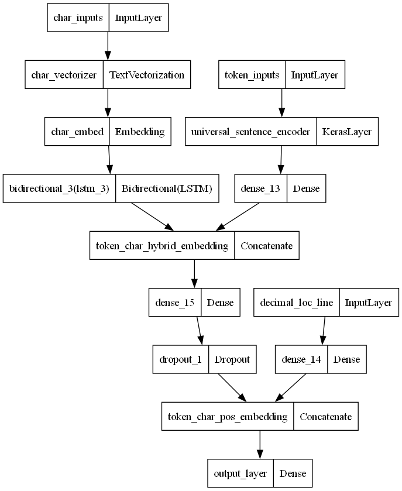

```python
from tensorflow.keras.utils import plot_model
plot_model(model_6)
```

next we'll compile the model, and also format the needed datasets into tf tensors.

```python
# Compile token, char, pos, embed model
model_6.compile(loss=tf.keras.losses.CategoricalCrossentropy(label_smoothing=0.2), # add label smoothing to improve generalization
                optimizer=tf.keras.optimizers.Adam(),
                metrics=['accuracy'])
```

we forgot to add an extra dimension for our decimal locality - as that is needed for the model to work, cuz of batch number

```python
# add an extra dimension
train_dec_loc = train_dec_loc.to_numpy().reshape(-1, 1).astype(np.float32)
val_dec_loc   = val_dec_loc.to_numpy().reshape(-1, 1).astype(np.float32)
```

```python
# create training and validation datasets
train_dec_char_token_data = tf.data.Dataset.from_tensor_slices((train_dec_loc, # decimal loc
                                                                train_sentences, # train tokens
                                                                train_chars)) # train chars
train_dec_char_token_labels = tf.data.Dataset.from_tensor_slices(train_labels_one_hot) # train labels
train_dec_char_token_dataset = tf.data.Dataset.zip((train_dec_char_token_data,train_dec_char_token_labels)) # combine 4 datasets and labels
train_dec_char_token_dataset = train_dec_char_token_dataset.batch(32).prefetch(tf.data.AUTOTUNE) # turn into batches and prefetch appropriately

# validation data
val_dec_char_token_data = tf.data.Dataset.from_tensor_slices((val_dec_loc,
                                                              val_sentences,
                                                              val_chars))
val_dec_char_token_labels = tf.data.Dataset.from_tensor_slices(val_labels_one_hot)
val_dec_char_token_dataset = tf.data.Dataset.zip((val_dec_char_token_data, val_dec_char_token_labels))
val_dec_char_token_dataset = val_dec_char_token_dataset.batch(32).prefetch(tf.data.AUTOTUNE) # turn into batches and prefetch appropriately

# Check input shapes
train_dec_char_token_dataset, val_dec_char_token_dataset
```

```
(<_PrefetchDataset element_spec=((TensorSpec(shape=(None, 1), dtype=tf.float32, name=None), TensorSpec(shape=(None,), dtype=tf.string, name=None), TensorSpec(shape=(None,), dtype=tf.string, name=None)), TensorSpec(shape=(None, 5), dtype=tf.float64, name=None))>,
 <_PrefetchDataset element_spec=((TensorSpec(shape=(None, 1), dtype=tf.float32, name=None), TensorSpec(shape=(None,), dtype=tf.string, name=None), TensorSpec(shape=(None,), dtype=tf.string, name=None)), TensorSpec(shape=(None, 5), dtype=tf.float64, name=None))>)
```

```python
# Fit the token, char and positional embedding model
history_model_6 = model_6.fit(train_dec_char_token_dataset,
                              steps_per_epoch=int(0.1 * len(train_dec_char_token_dataset)),
                              epochs=3,
                              validation_data=val_dec_char_token_dataset,
                              validation_steps=int(0.1 * len(val_dec_char_token_dataset)))
```

[output not shown]

> But why is that? So our `decimation locale` has values set between 0 and 1, which computers do like. The caveat to that, is they're working with float values, with non cleanly divisible numbers. This leaves some lines have 1 number, while you got recurring 3s or 9s, which can clog up the model.

More over, one hot encoding is as simple as `0` and `1`. Not needing to think about how big the value is. This may have caused even more strain and trouble for the model as well.

What could be done different? Maybe we can limit the float number to just 4 digits in total which may help speed up training, but most likely accuracy will stay the same due to no significant change to information, other than removin inperceptably small values.

5. Write a function (or series of functions) to take a sample abstract string, preprocess it (in the same way our model has been trained), make a prediction on each sequence in the abstract and return the abstract in the format:
- PREDICTED_LABEL: SEQUENCE
- PREDICTED_LABEL: SEQUENCE
- PREDICTED_LABEL: SEQUENCE
- PREDICTED_LABEL: SEQUENCE
- ...
  - You can find your own unstrcutured RCT abstract from PubMed or try this one from: Baclofen promotes alcohol abstinence in alcohol dependent cirrhotic patients with hepatitis C virus (HCV) infection.

This is said wild abstract we'll be playing with:

```
Hepatitis C virus (HCV) and alcoholic liver disease (ALD), either alone or in combination, count for more than two thirds of all liver diseases in the Western world. There is no safe level of drinking in HCV-infected patients and the most effective goal for these patients is total abstinence. Baclofen, a GABA(B) receptor agonist, represents a promising pharmacotherapy for alcohol dependence (AD). Previously, we performed a randomized clinical trial (RCT), which demonstrated the safety and efficacy of baclofen in patients affected by AD and cirrhosis. The goal of this post-hoc analysis was to explore baclofen's effect in a subgroup of alcohol-dependent HCV-infected cirrhotic patients. Any patient with HCV infection was selected for this analysis. Among the 84 subjects randomized in the main trial, 24 alcohol-dependent cirrhotic patients had a HCV infection; 12 received baclofen 10mg t.i.d. and 12 received placebo for 12-weeks. With respect to the placebo group (3/12, 25.0%), a significantly higher number of patients who achieved and maintained total alcohol abstinence was found in the baclofen group (10/12, 83.3%; p=0.0123). Furthermore, in the baclofen group, compared to placebo, there was a significantly higher increase in albumin values from baseline (p=0.0132) and a trend toward a significant reduction in INR levels from baseline (p=0.0716). In conclusion, baclofen was safe and significantly more effective than placebo in promoting alcohol abstinence, and improving some Liver Function Tests (LFTs) (i.e. albumin, INR) in alcohol-dependent HCV-infected cirrhotic patients. Baclofen may represent a clinically relevant alcohol pharmacotherapy for these patients.
```

Let's read the file, now that I added it into a .txt file - and form a function based on it

```python
# .txt abstract read function
def read_file(file):
    with open(file, "r") as f:
        return f.read()

wild_abstract = read_file("wild_abstract.txt")
print(wild_abstract)
```

```
Hepatitis C virus (HCV) and alcoholic liver disease (ALD), either alone or in combination, count for more than two thirds of all liver diseases in the Western world. There is no safe level of drinking in HCV-infected patients and the most effective goal for these patients is total abstinence. Baclof…
```

Next step is to import `spaCy`, so we can split the text based on its previous knowledge.

```python
# import spacy english
import spacy
from spacy.lang.en import English
nlp = English()

def sentence_splitter(abstract):
    sentencizer = nlp.add_pipe('sentencizer') # sentence splitter pipeline

    doc = nlp(abstract)
    abstract_lines = [str(sent) for sent in list(doc.sents)] # return detected sentences from doc
    return abstract_lines

sentenced = sentence_splitter(wild_abstract)
sentenced
```

```
['Hepatitis C virus (HCV) and alcoholic liver disease (ALD), either alone or in combination, count for more than two thirds of all liver diseases in the Western world.',
 'There is no safe level of drinking in HCV-infected patients and the most effective goal for these patients is total abstinence.',
 'Baclofen, a GABA(B) receptor agonist, represents a promising pharmacotherapy for alcohol dependence (AD).',
 'Previously, we performed a randomized clinical trial (RCT), which demonstrated the safety and efficacy of baclofen in patients affected by AD and cirrhosis.',
 "The goal of this post-hoc analysis was to explore baclofen's effect in a subgroup of alcohol-dependent HCV-infected cirrhotic patients.",
 'Any patient with HCV infection was selected for this analysis.',
 'Among the 84 subjects randomized in the main trial, 24 alcohol-dependent cirrhotic patients had a HCV infection; 12 received baclofen 10mg t.i.d.',
 'and 12 received placebo for 12-weeks.',
 'With respect to the placebo group (3/12, 25.0%), a significantly higher number of patients who achieved and maintained total alcohol abstinence was found in the baclofen group (10/12, 83.3%; p=0.0123).',
 'Furthermore, in the baclofen group, compared to placebo, there was a significantly higher increase in albumin values from baseline (p=0.0132) and a trend toward a significant reduction in INR levels from baseline (p=0.0716).',
 'In conclusion, baclofen was safe and significantly more effective than placebo in promoting alcohol abstinence, and improving some Liver Function Tests (LFTs) (i.e. albumin, INR) in alcohol-dependent HCV-infected cirrhotic patients.',
 'Baclofen may represent a clinically relevant alcohol pharmacotherapy for these patients.']
```

`spaCy` did quite well, probably just one that needed fixing:

```
 'Among the 84 subjects randomized in the main trial, 24 alcohol-dependent cirrhotic patients had a HCV infection; 12 received baclofen 10mg t.i.d.',
 'and 12 received placebo for 12-weeks.',
```

They should probably be combined, but let's see how it continues to perform anyways - Our next step is to add line information, and format it into a dictionary of data.

```python
# create line info and format into dict
total_line = len(sentenced) # get total num of lines
sample_lines = [] # list to store dict info

def get_lines (abstract,max_line):
    for i,line in enumerate(abstract):
        sample_dict={}
        sample_dict['text']=line
        sample_dict['line_number']=i
        sample_dict['total_number']=max_line-1
        sample_lines.append(sample_dict)
    return sample_lines

sample_lines = get_lines(sentenced, total_line)
sample_lines
```

```
[{'text': 'Hepatitis C virus (HCV) and alcoholic liver disease (ALD), either alone or in combination, count for more than two thirds of all liver diseases in the Western world.',
  'line_number': 0,
  'total_number': 11},
 {'text': 'There is no safe level of drinking in HCV-infected patients and the most effective goal for these patients is total abstinence.',
  'line_number': 1,
  'total_number': 11},
 {'text': 'Baclofen, a GABA(B) receptor agonist, represents a promising pharmacotherapy for alcohol dependence (AD).',
  'line_number': 2,
  'total_number': 11},
 {'text': 'Previously, we performed a randomized clinical trial (RCT), which demonstrated the safety and efficacy of baclofen in patients affected by AD and cirrhosis.',
  'line_number': 3,
  'total_number': 11},
 {'text': "The goal of this post-hoc analysis was to explore baclofen's effect in a subgroup of alcohol-dependent HCV-infected cirrhotic patients.",
  'line_number': 4,
  'total_number': 11},
 {'text': 'Any patient with HCV infection was selected for this analysis.',
  'line_number': 5,
  'total_number': 11},
 {'text': 'Among the 84 subjects randomized in the main trial, 24 alcohol-dependent cirrhotic patients had a HCV infection; 12 received baclofen 10mg t.i.d.',
  'line_number': 6,
  'total_number': 11},
 {'text': 'and 12 received placebo for 12-weeks.',
  'line_number': 7,
  'total_number': 11},
 {'text': 'With respect to the placebo group (3/12, 25.0%), a significantly higher number of patients who achieved and maintained total alcohol abstinence was found in the baclofen group (10/12, 83.3%; p=0.0123).',
  'line_number': 8,
  'total_number': 11},
 {'text': 'Furthermore, in the baclofen group, compared to placebo, there was a significantly higher increase in albumin values from baseline (p=0.0132) and a trend toward a significant reduction in INR levels from baseline (p=0.0716).',
  'line_number': 9,
  'total_number': 11},
 {'text': 'In conclusion, baclofen was safe and significantly more effective than placebo in promoting alcohol abstinence, and improving some Liver Function Tests (LFTs) (i.e. albumin, INR) in alcohol-dependent HCV-infected cirrhotic patients.',
  'line_number': 10,
  'total_number': 11},
 {'text': 'Baclofen may represent a clinically relevant alcohol pharmacotherapy for these patients.',
  'line_number': 11,
  'total_number': 11}]
```

> **Note**: Since we've made changes to `model_5`, and exchanged positional details for decimal locale, we will use `decimal locale`, as we have only trained that version of the model over the original.

Next is to preprocess all information, so it is ready character wise, and decimal wise.

```python
# create a function that takes in abstract sentence, and preprocess it into char/dec loc
dec_loc=[]
chars=[]
texts=[]

def preprocess(sample_lines):
    for item in sample_lines:
        # decimal locale
        real_pos = item['line_number']/item['total_number']
        dec_loc.append(real_pos)

        # token/word
        texts.append(item['text'])

        # characters
        chars .append(split_chars(item['text']))
    return dec_loc,chars,texts

dec_loc,chars,texts = preprocess(sample_lines)
dec_loc,chars,texts
```

```
([0.0,
  0.09090909090909091,
  0.18181818181818182,
  0.2727272727272727,
  0.36363636363636365,
  0.45454545454545453,
  0.5454545454545454,
  0.6363636363636364,
  0.7272727272727273,
  0.8181818181818182,
  0.9090909090909091,
  1.0],
 ['H e p a t i t i s   C   v i r u s   ( H C V )   a n d   a l c o h o l i c   l i v e r   d i s e a s e   ( A L D ) ,   e i t h e r   a l o n e   o r   i n   c o m b i n a t i o n ,   c o u n t   f o r   m o r e   t h a n   t w o   t h i r d s   o f   a l l   l i v e r   d i s e a s e s   i n   t h…
  'T h e r e   i s   n o   s a f e   l e v e l   o f   d r i n k i n g   i n   H C V - i n f e c t e d   p a t i e n t s   a n d   t h e   m o s t   e f f e c t i v e   g o a l   f o r   t h e s e   p a t i e n t s   i s   t o t a l   a b s t i n e n c e .',
  'B a c l o f e n ,   a   G A B A ( B )   r e c e p t o r   a g o n i s t ,   r e p r e s e n t s   a   p r o m i s i n g   p h a r m a c o t h e r a p y   f o r   a l c o h o l   d e p e n d e n c e   ( A D ) .',
  'P r e v i o u s l y ,   w e   p e r f o r m e d   a   r a n d o m i z e d   c l i n i c a l   t r i a l   ( R C T ) ,   w h i c h   d e m o n s t r a t e d   t h e   s a f e t y   a n d   e f f i c a c y   o f   b a c l o f e n   i n   p a t i e n t s   a f f e c t e d   b y   A D   a n d   c i r…
  "T h e   g o a l   o f   t h i s   p o s t - h o c   a n a l y s i s   w a s   t o   e x p l o r e   b a c l o f e n ' s   e f f e c t   i n   a   s u b g r o u p   o f   a l c o h o l - d e p e n d e n t   H C V - i n f e c t e d   c i r r h o t i c   p a t i e n t s .",
  'A n y   p a t i e n t   w i t h   H C V   i n f e c t i o n   w a s   s e l e c t e d   f o r   t h i s   a n a l y s i s .',
  'A m o n g   t h e   8 4   s u b j e c t s   r a n d o m i z e d   i n   t h e   m a i n   t r i a l ,   2 4   a l c o h o l - d e p e n d e n t   c i r r h o t i c   p a t i e n t s   h a d   a   H C V   i n f e c t i o n ;   1 2   r e c e i v e d   b a c l o f e n   1 0 m g   t . i . d .',
  'a n d   1 2   r e c e i v e d   p l a c e b o   f o r   1 2 - w e e k s .',
  'W i t h   r e s p e c t   t o   t h e   p l a c e b o   g r o u p   ( 3 / 1 2 ,   2 5 . 0 % ) ,   a   s i g n i f i c a n t l y   h i g h e r   n u m b e r   o f   p a t i e n t s   w h o   a c h i e v e d   a n d   m a i n t a i n e d   t o t a l   a l c o h o l   a b s t i n e n c e   w a s   f…
  'F u r t h e r m o r e ,   i n   t h e   b a c l o f e n   g r o u p ,   c o m p a r e d   t o   p l a c e b o ,   t h e r e   w a s   a   s i g n i f i c a n t l y   h i g h e r   i n c r e a s e   i n   a l b u m i n   v a l u e s   f r o m   b a s e l i n e   ( p = 0 . 0 1 3 2 )   a n d   a   t…
  'I n   c o n c l u s i o n ,   b a c l o f e n   w a s   s a f e   a n d   s i g n i f i c a n t l y   m o r e   e f f e c t i v e   t h a n   p l a c e b o   i n   p r o m o t i n g   a l c o h o l   a b s t i n e n c e ,   a n d   i m p r o v i n g   s o m e   L i v e r   F u n c t i o n   T e s…
  'B a c l o f e n   m a y   r e p r e s e n t   a   c l i n i c a l l y   r e l e v a n t   a l c o h o l   p h a r m a c o t h e r a p y   f o r   t h e s e   p a t i e n t s .'],
 ['Hepatitis C virus (HCV) and alcoholic liver disease (ALD), either alone or in combination, count for more than two thirds of all liver diseases in the Western world.',
  'There is no safe level of drinking in HCV-infected patients and the most effective goal for these patients is total abstinence.',
  'Baclofen, a GABA(B) receptor agonist, represents a promising pharmacotherapy for alcohol dependence (AD).',
  'Previously, we performed a randomized clinical trial (RCT), which demonstrated the safety and efficacy of baclofen in patients affected by AD and cirrhosis.',
  "The goal of this post-hoc analysis was to explore baclofen's effect in a subgroup of alcohol-dependent HCV-infected cirrhotic patients.",
  'Any patient with HCV infection was selected for this analysis.',
  'Among the 84 subjects randomized in the main trial, 24 alcohol-dependent cirrhotic patients had a HCV infection; 12 received baclofen 10mg t.i.d.',
  'and 12 received placebo for 12-weeks.',
  'With respect to the placebo group (3/12, 25.0%), a significantly higher number of patients who achieved and maintained total alcohol abstinence was found in the baclofen group (10/12, 83.3%; p=0.0123).',
  'Furthermore, in the baclofen group, compared to placebo, there was a significantly higher increase in albumin values from baseline (p=0.0132) and a trend toward a significant reduction in INR levels from baseline (p=0.0716).',
  'In conclusion, baclofen was safe and significantly more effective than placebo in promoting alcohol abstinence, and improving some Liver Function Tests (LFTs) (i.e. albumin, INR) in alcohol-dependent HCV-infected cirrhotic patients.',
  'Baclofen may represent a clinically relevant alcohol pharmacotherapy for these patients.'])
```

Next step is to put through the model and make prediction.

```python
# make prediction on sample
def tf_convert(wild_dataset):
        wild_dataset = tf.data.Dataset.from_tensor_slices(({ # turn them into tensors, and in batches of 32
                "decimal_loc_line": dec_loc,
                "token_inputs": texts,
                "char_inputs": chars})).batch(32)

        preds = model_6.predict(wild_dataset)
        return preds

preds = tf_convert(wild_dataset)
preds
```

```
array([[0.16970086, 0.08133141, 0.5107869 , 0.08942729, 0.1487536 ],
       [0.27885273, 0.38138422, 0.05381954, 0.1436269 , 0.1423166 ],
       [0.4195803 , 0.18205935, 0.08097885, 0.26818866, 0.04919287],
       [0.37891716, 0.08308292, 0.26320702, 0.2281495 , 0.04664349],
       [0.23558873, 0.09828301, 0.09799621, 0.4852533 , 0.08287872],
       [0.04895346, 0.07864064, 0.4981077 , 0.04973892, 0.3245593 ],
       [0.06017731, 0.0689042 , 0.32462114, 0.0573131 , 0.48898432],
       [0.05004208, 0.06179035, 0.6798945 , 0.04386547, 0.16440758],
       [0.05320551, 0.08615397, 0.10854992, 0.04428265, 0.7078079 ],
       [0.04053989, 0.25363076, 0.02175589, 0.03023982, 0.6538336 ],
       [0.14758722, 0.51481116, 0.05196028, 0.11863195, 0.16700938],
       [0.08780371, 0.84784764, 0.01274536, 0.04416602, 0.00743726]],
      dtype=float32)
```

Finally, let's check the prediction and add it onto the sample abstract

```python
# check predictions
pred_classes=[]
def class_preds(preds):
    abstract_pred = tf.argmax(preds,axis=1)

    pred_classes = [label_encoder.classes_[i] for i in abstract_pred]
    return pred_classes

pred_classes = class_preds(preds)
pred_classes
```

```
['METHODS',
 'CONCLUSIONS',
 'BACKGROUND',
 'BACKGROUND',
 'OBJECTIVE',
 'METHODS',
 'RESULTS',
 'METHODS',
 'RESULTS',
 'RESULTS',
 'CONCLUSIONS',
 'CONCLUSIONS']
```

Next step, let's add a new column for `PREDICTED_LABEL` onto our `sample_lines`

```python
def add_label(sample_lines, pred_classes):
    for i, line in enumerate(sample_lines):
        line['PREDICTED_LABEL'] = pred_classes[i]
    return sample_lines

# Example usage
sample_lines_with_preds = add_label(sample_lines, pred_classes)
sample_lines_with_preds
```

```
[{'text': 'Hepatitis C virus (HCV) and alcoholic liver disease (ALD), either alone or in combination, count for more than two thirds of all liver diseases in the Western world.',
  'line_number': 0,
  'total_number': 11,
  'PREDICTED_LABEL': 'METHODS'},
 {'text': 'There is no safe level of drinking in HCV-infected patients and the most effective goal for these patients is total abstinence.',
  'line_number': 1,
  'total_number': 11,
  'PREDICTED_LABEL': 'CONCLUSIONS'},
 {'text': 'Baclofen, a GABA(B) receptor agonist, represents a promising pharmacotherapy for alcohol dependence (AD).',
  'line_number': 2,
  'total_number': 11,
  'PREDICTED_LABEL': 'BACKGROUND'},
 {'text': 'Previously, we performed a randomized clinical trial (RCT), which demonstrated the safety and efficacy of baclofen in patients affected by AD and cirrhosis.',
  'line_number': 3,
  'total_number': 11,
  'PREDICTED_LABEL': 'BACKGROUND'},
 {'text': "The goal of this post-hoc analysis was to explore baclofen's effect in a subgroup of alcohol-dependent HCV-infected cirrhotic patients.",
  'line_number': 4,
  'total_number': 11,
  'PREDICTED_LABEL': 'OBJECTIVE'},
 {'text': 'Any patient with HCV infection was selected for this analysis.',
  'line_number': 5,
  'total_number': 11,
  'PREDICTED_LABEL': 'METHODS'},
 {'text': 'Among the 84 subjects randomized in the main trial, 24 alcohol-dependent cirrhotic patients had a HCV infection; 12 received baclofen 10mg t.i.d.',
  'line_number': 6,
  'total_number': 11,
  'PREDICTED_LABEL': 'RESULTS'},
 {'text': 'and 12 received placebo for 12-weeks.',
  'line_number': 7,
  'total_number': 11,
  'PREDICTED_LABEL': 'METHODS'},
 {'text': 'With respect to the placebo group (3/12, 25.0%), a significantly higher number of patients who achieved and maintained total alcohol abstinence was found in the baclofen group (10/12, 83.3%; p=0.0123).',
  'line_number': 8,
  'total_number': 11,
  'PREDICTED_LABEL': 'RESULTS'},
 {'text': 'Furthermore, in the baclofen group, compared to placebo, there was a significantly higher increase in albumin values from baseline (p=0.0132) and a trend toward a significant reduction in INR levels from baseline (p=0.0716).',
  'line_number': 9,
  'total_number': 11,
  'PREDICTED_LABEL': 'RESULTS'},
 {'text': 'In conclusion, baclofen was safe and significantly more effective than placebo in promoting alcohol abstinence, and improving some Liver Function Tests (LFTs) (i.e. albumin, INR) in alcohol-dependent HCV-infected cirrhotic patients.',
  'line_number': 10,
  'total_number': 11,
  'PREDICTED_LABEL': 'CONCLUSIONS'},
 {'text': 'Baclofen may represent a clinically relevant alcohol pharmacotherapy for these patients.',
  'line_number': 11,
  'total_number': 11,
  'PREDICTED_LABEL': 'CONCLUSIONS'}]
```

{% endraw %}